# Loading epigraphic data and basic descriptive statistics

Petra Hermankova[^1]

2025-03-27

*Purpose of this script is a basic exploration of the contents of inscriptions and its attributes.*

# 1 Initial setup

```r
knitr::opts_chunk$set(message = FALSE, warning = FALSE)

# Install required packages if not already installed
if (!requireNamespace("jsonlite", quietly = TRUE)) install.packages("jsonlite")
if (!requireNamespace("dplyr", quietly = TRUE)) install.packages("dplyr")
if (!requireNamespace("ggplot2", quietly = TRUE)) install.packages("ggplot2")
if (!requireNamespace("tidytext", quietly = TRUE)) install.packages("tidytext")
if (!requireNamespace("raster", quietly = TRUE)) install.packages("raster")
if (!requireNamespace("tidyverse", quietly = TRUE)) install.packages("tidyverse")
if (!requireNamespace("sf", quietly = TRUE)) install.packages("sf")
if (!requireNamespace("xml2", quietly = TRUE)) install.packages("xml2")
if (!requireNamespace("leaflet", quietly = TRUE)) install.packages("leaflet")
if (!requireNamespace("htmlwidgets", quietly = TRUE)) install.packages("htmlwidgets")

# Load necessary libraries
library(tidyverse)
library(jsonlite)
library(tidytext)
library(xml2)
library(dplyr)
library(leaflet)
library(raster)
library(sf)
library(ggplot2)
library(htmlwidgets)
```

# 2 Working with inscriptions in R

## 2.1 Display the current working directory

```r
getwd()
```

```
## [1] "/home/au648560/Github/stone_to_computeR/scripts"
```

## 2.2 List files in the current directory

```r
list.files()
```

```
## [1] "1_load_and_explore.html"       "1_load_and_explore.Rmd"
## [3] "2_mine_and_visualise.Rmd"      "tumulus_inscriptions_map.html"
```

## 2.3 Create a variable

```r
x <- 10
y <- 5
z <- "dis manibus"
w <- "Pictos / victos / hostis / deleta / ludite / securi"
```

## 2.4 Simple computation

```r
number <- x + y
number
```

```
## [1] 15
```

## 2.5 Running Existing Code and Commenting on Code

```r
# This is a comment. I can write whatever I want and the computer will not see it, unless I remove the ####.

# Running existing code
numbers <- c(1,3,5,6, 89, 3878) # creates a new numeric vector
summary(numbers) # provides basic stat overview of the vector
```

```
##    Min. 1st Qu.  Median    Mean 3rd Qu.    Max.
##    1.00    3.50    5.50  663.67   68.25 3878.00
```

## 2.6 Simple plot

```r
# Create a dataframe with variable1 and variable2
data <- data.frame(
  variable1 = c(1, 2, 5, 7, 8, 1, 33, 24, 234),
  variable2 = c(12, 2, 3, 7, 1, 1, 331, 24, 24)
)

# Display the dataframe
print(data)
```

```
##   variable1 variable2
## 1         1        12
## 2         2         2
## 3         5         3
## 4         7         7
## 5         8         1
## 6         1         1
## 7        33       331
## 8        24        24
## 9       234        24
```

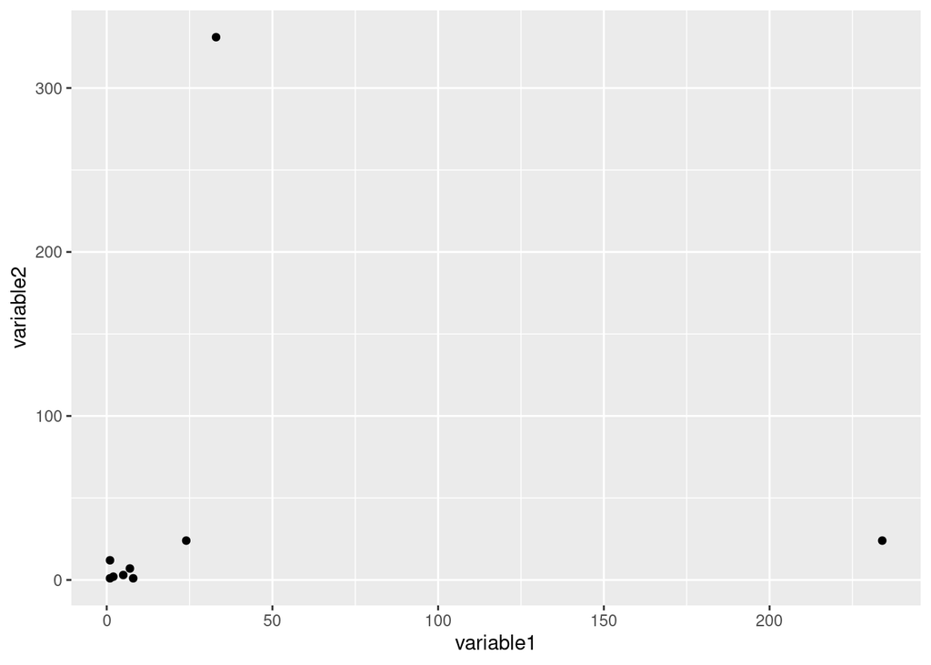

```r
# Create a plot
plot <- ggplot(data, aes(x = variable1, y = variable2)) + geom_point()
# Display the plot
plot
```

## 2.7 Saving plots and resuts as CSV

```r
# Save the plot
ggsave("../figures/plot_test.png", plot)

# Save results to a CSV file
write.csv(data, "../data/results_test.csv")
```

# 3 Loading epigraphic data in R

**Before You Begin**

- Make sure you have R and RStudio installed
- Install required libraries
- Ensure your data files are in the correct directory and you know how to navigate to it

## 3.1 Load data from a CSV file

- Use the read.csv() function to load CSV (Comma-Separated Values) files
- Basic syntax: dataName <- read.csv(“path/to/your/file.csv”)
- Replace dataName with a meaningful variable name
- Replace the file path with the location of your specific CSV file

```r
dataCSV <- read.csv("../data/results_test.csv")
```

## 3.2 Load data from a TSV file

- Use the read_tsv() function from the readr library to load TSV (Tab-Separated Values) files
- First, make sure to load the readr library with library(readr)
- Basic syntax: dataName <- read_tsv(“path/to/your/file.tsv”)
- Replace dataName with a meaningful variable name
- Replace the file path with the location of your specific TSV file

```r
tumulusTSV <- read_tsv("../data/2025-03-10-EDCS_via_Lat_Epig-term1_tumulus-74.tsv")
```

## 3.3 Load data from a JSON file

- Use the fromJSON() function from the jsonlite library to load JSON (JavaScript Object Notation) files
- First, make sure to install and load the jsonlite library with install.packages(“jsonlite”) and library(jsonlite)
- Basic syntax: dataName <- jsonlite::fromJSON(“path/to/your/file.json”)
- Replace dataName with a meaningful variable name
- Replace the file path with the location of your specific JSON file
- Consider printing the first few rows of your data using head() to verify it loaded correctly to access specific parts of the JSON data
- Convert to a tibble (data frame) using as_tibble() if needed for better visual organisation

NOTE: Some JSON files have nested structures, so they might be more difficult to load.

```r
tumulusJSON <- jsonlite::fromJSON("../data/2025-03-10-EDCS_via_Lat_Epig-term1_tumulus-74.json")
tumulus <- as_tibble(tumulusJSON$data)

head(tumulus) # print the first six rows
```

| EDCS-ID | publication | province | place | dating_from | dating_to | date_not_before | date_not_after | status | inscription | inscription_conservative_cleaning | inscription_interpretive_cleaning | material | comment | latitude | longitude | language | photo | partner_link | extra_text | extra_html | raw_dating |
| --- | --- | --- | --- | --- | --- | --- | --- | --- | --- | --- | --- | --- | --- | --- | --- | --- | --- | --- | --- | --- | --- |
| EDCS-20401782 | CIL 11, 00330 = ILCV 03874 | Aemilia / Regio VIII | Ravenna |  |  |  |  | inscriptiones christianae; nomen singulare; tituli operum; tituli sepulcrales; viri | Tumulus iste docet cuius retinet corpus / Sergius vocita(b)ar levitis fungeat (h)onore(m) / (h)uius martyris aul(a)e at pueritia deservivit / per ipsu(m) preco cuncti iam ut nunquam (h)ic aliut pon(a)… | Tumulus iste docet cuius retinet corpus Sergius vocitaar levitis fungeVat onore uius martyris aule at pueritia deservivit per ipsu preco cuncti iam ut nunquam ic aliut pont | Tumulus iste docet cuius retinet corpus Sergius vocitabar levitis fungebat honorem huius martyris aulae at pueritia deservivit per ipsum preco cuncti iam ut nunquam hic aliut ponatur | lapis | NA | 44.4161414 | 12.2017617 |  | NA | http://db.edcs.eu/epigr/partner.php?s_language=en&param=m\|appe\|0622;bu_ILCV%26bibl_volume=%26bibl_subvolume=%26bibl_insc=3874 |  |  | NA |
| EDCS-16800123 | CIL 08, 27380 = ILTun-01, 01525 = CLE 01971 = CLENuovo p 139 = MAD 01541 = CLEAfrique 00056 = AE 1990, +01040 | Africa proconsularis | Ben Ismail, Hr. / Bou Ismail, Hr. / Thugga |  |  |  |  | carmina; mulieres; tituli operum; tituli sepulcrales; tria nomina | Dis est sacratus Manibus / hic tumulus / qui tegit ossa piae / C[3]ae V(ibi) f(iliae) Numisiae / Marcell[in]ae Quinti / [3]O[3 uxo]ris / quorum quo sic sunt / coniuncta sepulcra / testantur quam conco… | Dis est sacratus Manibus hic tumulus qui tegit ossa piae C ae V f Numisiae Marcell ae Quinti O ris quorum quoT sic sunt coniuncta sepulcra testantur quam concordes exegerint aevOm quos nec mors potuit… | Dis est sacratus Manibus hic tumulus qui tegit ossa piae C ae Vibi filiae Numisiae Marcellinae Quinti O uxoris quorum quod sic sunt coniuncta sepulcra testantur quam concordes exegerint aevum quos nec… | lapis | NA | 36.4068686 | 9.2327361 |  | http://db.edcs.eu/epigr/bilder.php?bilder.php?s_language=en&bild=PEC0011254 | http://db.edcs.eu/epigr/partner.php?s_language=en&param=ko0054571;G120100200883;ra_DU070EP003;m\|ce\|1971;bu_ILTun%26bibl_volume=%26bibl_subvolume=%26bibl_insc=1525 |  |  | NA |
| EDCS-53500004 | CLEAfrique 00049 = EChrAfr-03, 00177 | Africa proconsularis | Carthago |  |  |  |  | carmina; tituli sepulcrales; viri | Venator iucunde nimis atque arte ferarum / saepe placens agilis gratus fortissimus audax / qui puer ad iuvenes dum non adiunxeris annos / omnia maturo conplebas facta labore / qui licet ex propria pop… | Venator iucunde nimis at que arte ferarum saepe placens agilis gratus fortissimus audax qui puer ad iuvenes dum non adiunxeris annos omnia maturo conplebas facta labore qui licet ex propria populis be… | Venator iucunde nimis at que arte ferarum saepe placens agilis gratus fortissimus audax qui puer ad iuvenes dum non adiunxeris annos omnia maturo conplebas facta labore qui licet ex propria populis be… | NA | NA | 36.8527778 | 10.3233333 |  | NA |  |  |  | NA |
| EDCS-02000004 | AE 1915, 00073 | Africa proconsularis | Dougga / Thugga |  |  |  |  | mulieres; tituli operum; tituli sepulcrales; tria nomina; viri | Dis est sacratus Manibus / hic tumulus / qui tegit ossa piae / C[3]ae Numisiae / Marcell[in]ae Quinti / [3]O[3]RIS / quorum quo sic sunt / coniuncta sepulcra / testantur quam concor/des exegerint aevm… | Dis est sacratus Manibus hic tumulus qui tegit ossa piae C ae Numisiae Marcell ae Quinti O RIS quorum quoT sic sunt coniuncta sepulcra testantur quam concordes exegerint aevOm quos nec mors potuit sei… | Dis est sacratus Manibus hic tumulus qui tegit ossa piae C ae Numisiae Marcellinae Quinti O RIS quorum quod sic sunt coniuncta sepulcra testantur quam concordes exegerint aevum quos nec mors potuit se… | lapis | NA | 36.4234669 | 9.21869726 |  | NA | http://db.edcs.eu/epigr/partner.php?s_language=en&param=HD029379;1ae1915-18 |  |  | NA |
| EDCS-12401548 | CIL 09, 02043 = CLE 01271 | Apulia et Calabria / Regio II | Benevento / Beneventum | 101 | 200 | 101 | 200 | carmina; tituli operum; tituli sepulcrales | Hic tumulus parvus nihil habet [in]vidiae / nec nimium iactat commendat et simul / optat ut cives similes habeat felix / Beneventum | Hic tumulus parvus nihil habet vidiae nec nimium iactat commendat et simul optat ut cives similes habeat felix Beneventum | Hic tumulus parvus nihil habet invidiae nec nimium iactat commendat et simul optat ut cives similes habeat felix Beneventum | lapis | NA | 41.1295587 | 14.7824639 |  | NA | http://db.edcs.eu/epigr/partner.php?s_language=en&param=cil09_p308;m\|ce\|1271;N191006 |  |  | 101 to 200 |
| EDCS-56100156 | CAG-12, p 361 | Aquitani(c)a | Riviere-sur-Tarn |  |  |  |  | NA | Marini fa/bri tignar(ii) / tumul(us) | Marini fabri tignar tumul | Marini fabri tignarii tumulus | NA | NA | 44.1883973 | 3.1322855 |  | http://db.edcs.eu/epigr/bilder.php?bilder.php?s_language=en&bild=$CAG-12_p361.jpg |  |  |  | NA |

## 3.4 Load data from a EpiDoc file - single file

Used Claude.ai v3.7 to generate the code.

- This is to demonstrate hoe complex it is to extract any data out of XML, however useful format it is for epigraphy
- You need to know the structure of the XML and its tags to be able to extract any meaningful data

```r
# Install required packages if not already installed
if (!require("xml2")) install.packages("xml2")
if (!require("dplyr")) install.packages("dplyr")

# Load necessary libraries
library(xml2)
library(dplyr)

# Function to parse EpiDoc file to dataframe
parse_epidoc <- function(file_path) {
  # Read the XML file
  xml_data <- read_xml(file_path)

  # Get the namespace - this is critical for TEI XML
  ns <- xml_ns(xml_data)

  # Create an empty list to store our extracted data
  data_list <- list()

  # Extract basic info with namespace handling
  data_list$filename <- xml_text(xml_find_first(xml_data, "//d1:publicationStmt/d1:idno[@type='filename']", ns))
  data_list$title <- xml_text(xml_find_first(xml_data, "//d1:titleStmt/d1:title", ns))

  # Extract identifiers
  id_types <- c("filename", "TM", "EDR", "EDH", "EDCS", "PHI", "URI", "DOI")
  for (id_type in id_types) {
    xpath <- sprintf("//d1:publicationStmt/d1:idno[@type='%s']", id_type)
    node <- xml_find_first(xml_data, xpath, ns)
    if (!is.na(node)) {
      data_list[[paste0("id_", id_type)]] <- xml_text(node)
    }
  }

  # Extract editors
  editors <- xml_find_all(xml_data, "//d1:titleStmt/d1:editor", ns)
  if (length(editors) > 0) {
    data_list$editors <- paste(sapply(editors, xml_text), collapse = "; ")
  }

  # Extract location info
  origPlace <- xml_find_first(xml_data, "//d1:origin/d1:origPlace", ns)
  if (!is.na(origPlace)) {
    ancient_place <- xml_find_first(origPlace, "./d1:placeName[@type='ancient']", ns)
    if (!is.na(ancient_place)) {
      data_list$ancient_place <- xml_text(ancient_place)
      data_list$ancient_place_ref <- xml_attr(ancient_place, "ref")
      data_list$ancient_place_certainty <- xml_attr(ancient_place, "cert")
    }

    modern_place <- xml_find_first(origPlace, "./d1:placeName[@type='modern']", ns)
    if (!is.na(modern_place)) {
      data_list$modern_place <- xml_text(modern_place)
      data_list$modern_place_ref <- xml_attr(modern_place, "ref")
    }

    geo <- xml_find_first(origPlace, "./d1:geo", ns)
    if (!is.na(geo)) {
      coords <- xml_text(geo)
      data_list$geo_coords <- coords

      # Parse coordinates if they're in the "lat, long" format
      coords_split <- strsplit(coords, ",")[[1]]
      if (length(coords_split) == 2) {
        data_list$latitude <- as.numeric(trimws(coords_split[1]))
        data_list$longitude <- as.numeric(trimws(coords_split[2]))
      }
    }
  }

  # Extract dating info
  date_node <- xml_find_first(xml_data, "//d1:origin/d1:origDate", ns)
  if (!is.na(date_node)) {
    data_list$date_text <- xml_text(date_node)
    data_list$date_method <- xml_attr(date_node, "datingMethod")
    data_list$date_not_before <- xml_attr(date_node, "notBefore-custom")
    data_list$date_not_after <- xml_attr(date_node, "notAfter-custom")
  }

  # Extract material info
  material_node <- xml_find_first(xml_data, "//d1:support/d1:material", ns)
  if (!is.na(material_node)) {
    data_list$material <- xml_text(material_node)
    data_list$material_ref <- xml_attr(material_node, "ref")
  }

  # Extract language info
  lang_node <- xml_find_first(xml_data, "//d1:msContents/d1:textLang", ns)
  if (!is.na(lang_node)) {
    data_list$language <- xml_text(lang_node)
    data_list$main_lang <- xml_attr(lang_node, "mainLang")
  }

  # Extract repository/museum info
  repository_node <- xml_find_first(xml_data, "//d1:repository", ns)
  if (!is.na(repository_node)) {
    data_list$repository <- xml_text(repository_node)
    data_list$repository_role <- xml_attr(repository_node, "role")
    data_list$repository_ref <- xml_attr(repository_node, "ref")
  }

  # Extract inventory number
  inventory_node <- xml_find_first(xml_data, "//d1:idno[@type='inventory']", ns)
  if (!is.na(inventory_node)) {
    data_list$inventory <- xml_text(inventory_node)
  }

  # Extract inscription text
  ab_node <- xml_find_first(xml_data, "//d1:div[@type='edition']/d1:ab", ns)
  if (!is.na(ab_node)) {
    data_list$inscription_text <- xml_text(ab_node)
    # Get the language of the inscription text
    data_list$inscription_lang <- xml_attr(xml_find_first(xml_data, "//d1:div[@type='edition']", ns), "xml:lang")
  }

  # Extract named entities
  names <- xml_find_all(xml_data, "//d1:div[@type='edition']//d1:name", ns)
  if (length(names) > 0) {
    data_list$named_entities <- paste(sapply(names, xml_text), collapse = "; ")
  }

  # Extract line breaks information
  lb_nodes <- xml_find_all(xml_data, "//d1:div[@type='edition']//d1:lb", ns)
  if (length(lb_nodes) > 0) {
    line_numbers <- xml_attr(lb_nodes, "n")
    data_list$line_count <- length(lb_nodes)
    data_list$line_numbers <- paste(line_numbers, collapse = "; ")
  }

  # Extract abbreviations and their expansions
  abbr_nodes <- xml_find_all(xml_data, "//d1:div[@type='edition']//d1:abbr", ns)
  if (length(abbr_nodes) > 0) {
    abbreviations <- sapply(abbr_nodes, xml_text)
    data_list$abbreviations <- paste(abbreviations, collapse = "; ")
  }

  ex_nodes <- xml_find_all(xml_data, "//d1:div[@type='edition']//d1:ex", ns)
  if (length(ex_nodes) > 0) {
    expansions <- sapply(ex_nodes, xml_text)
    data_list$expansions <- paste(expansions, collapse = "; ")
  }

  # Extract gaps and unclear text
  gap_nodes <- xml_find_all(xml_data, "//d1:div[@type='edition']//d1:gap", ns)
  if (length(gap_nodes) > 0) {
    gap_info <- c()
    for (node in gap_nodes) {
      reason <- xml_attr(node, "reason")
      extent <- xml_attr(node, "extent")
      unit <- xml_attr(node, "unit")
      gap_info <- c(gap_info, paste(reason, extent, unit, sep=":"))
    }
    data_list$gaps <- paste(gap_info, collapse = "; ")
  }

  unclear_nodes <- xml_find_all(xml_data, "//d1:div[@type='edition']//d1:unclear", ns)
  if (length(unclear_nodes) > 0) {
    unclear_text <- sapply(unclear_nodes, xml_text)
    data_list$unclear_text <- paste(unclear_text, collapse = "; ")
  }

  # Extract bibliography references
  bibl_nodes <- xml_find_all(xml_data, "//d1:div[@type='bibliography']//d1:bibl", ns)
  if (length(bibl_nodes) > 0) {
    bibl_info <- c()
    for (node in bibl_nodes) {
      bibl_type <- xml_attr(node, "type")
      bibl_n <- xml_attr(node, "n")
      cited_range <- xml_text(xml_find_first(node, ".//d1:citedRange", ns))
      bibl_info <- c(bibl_info, paste(c(bibl_type, bibl_n, cited_range), collapse=":"))
    }
    data_list$bibliography <- paste(bibl_info, collapse = "; ")
  }

  # Convert list to dataframe, handling NULLs
  df <- as.data.frame(lapply(data_list, function(x) if(is.null(x)) NA else x), stringsAsFactors = FALSE)
  return(as_tibble(df))
}

# Process the file
file_path <- "../data/Epidoc/ISic0001.xml"  # Adjust this to your file path
inscription_df <- parse_epidoc(file_path)

# Print results
print(inscription_df)
```

```
## # A tibble: 1 × 38
##   filename title    id_filename id_TM id_EDR id_EDH id_EDCS id_PHI id_URI id_DOI
##   <chr>    <chr>    <chr>       <chr> <chr>  <chr>  <chr>   <chr>  <chr>  <chr>
## 1 ISic0001 Funerar… ISic0001    4916… ""     ""     219005… ""     http:… 10.52…
## # ℹ 28 more variables: editors <chr>, ancient_place <chr>,
## #   ancient_place_ref <chr>, ancient_place_certainty <chr>, modern_place <chr>,
## #   modern_place_ref <chr>, geo_coords <chr>, latitude <dbl>, longitude <dbl>,
## #   date_text <chr>, date_method <chr>, date_not_before <chr>,
## #   date_not_after <chr>, material <chr>, material_ref <chr>, language <chr>,
## #   main_lang <chr>, repository <chr>, repository_role <chr>,
## #   repository_ref <chr>, inventory <chr>, inscription_text <chr>, …
```

```r
# To show all columns in a readable format:
for (col in names(inscription_df)) {
  cat(paste0(col, ": ", inscription_df[[col]], "\n"))
}
```

```
## filename: ISic0001
## title: Funerary inscription
## id_filename: ISic0001
## id_TM: 491696
## id_EDR:
## id_EDH:
## id_EDCS: 21900531
## id_PHI:
## id_URI: http://sicily.classics.ox.ac.uk/inscription/ISic0001
## id_DOI: 10.5281/zenodo.4333721
## editors: Jonathan Prag
## ancient_place:
## ancient_place_ref: NA
## ancient_place_certainty: NA
## modern_place: Caltanissetta
## modern_place_ref: http://sws.geonames.org/2525448
## geo_coords: 37.49025, 14.06216
## latitude: 37.49025
## longitude: 14.06216
## date_text: Imperial
## date_method: #julian
## date_not_before: 0001
## date_not_after: 0300
## material: marble
## material_ref: http://www.eagle-network.eu/voc/material/lod/48.html
## language: Latin
## main_lang: la
## repository: Museo Archeologico Regionale Antonino Salinas
## repository_role: museum
## repository_ref: http://sicily.classics.ox.ac.uk/museum/064
## inventory: 3501
## inscription_text:
##                     Dis · manibus
##                     Zethi
##                     vixit · annis · VI
##
## inscription_lang: NA
## line_count: 3
## line_numbers: 1; 2; 3
## abbreviations: man; a
## expansions: ibus; nnis
## bibliography: NA:NA:cl.14 no.147; corpus:CIL:10.7190; corpus:ILMusPalermo:1; NA:NA:NA; NA:NA:NA
```

```r
# Save to CSV if needed
 write.csv(inscription_df, "../data/Epidoc_inscription_data.csv", row.names = FALSE)
```

`Exercise: Compare the original Epidoc file with the extracted information. What imporantant information (for you) is currently not being extracted? Can you try?`

## 3.5 Load data from a EpiDoc file - multiple files

Used Claude.ai v3.7 to generate the code.

This section demonstrates how to extract information from multiple XML files. Be ware, that not every XML has the same structure, or contains the same attributes. You may need to modify the code, depending on your project and the structure of your data. Feel free to add AI as your coding partner (I personally recommend Claude.ai for coding).

```r
# Install required packages if not already installed
if (!require("xml2")) install.packages("xml2")
if (!require("dplyr")) install.packages("dplyr")

# Load necessary libraries
library(xml2)
library(dplyr)

# Enhanced parse_epidoc function with better handling of structural differences
parse_epidoc <- function(file_path) {
  # Read the XML file
  xml_data <- read_xml(file_path)

  # Get the namespace - this is critical for TEI XML
  ns <- xml_ns(xml_data)

  # Create an empty list to store our extracted data
  data_list <- list()

  # Always store the filename regardless of structure
  data_list$filename <- basename(file_path)

  # Function to safely extract text from XML nodes
  safe_xml_text <- function(xpath, default_value = NA) {
    node <- xml_find_first(xml_data, xpath, ns)
    if (!is.na(node)) {
      return(xml_text(node))
    } else {
      return(default_value)
    }
  }

  # Function to safely extract attribute from XML nodes
  safe_xml_attr <- function(xpath, attr_name, default_value = NA) {
    node <- xml_find_first(xml_data, xpath, ns)
    if (!is.na(node)) {
      attr_value <- xml_attr(node, attr_name)
      if (!is.na(attr_value)) {
        return(attr_value)
      }
    }
    return(default_value)
  }

  # Try multiple possible XPaths for common elements
  # For example, title might be in different locations
  title_xpaths <- c(
    "//d1:titleStmt/d1:title",
    "//tei:titleStmt/tei:title",
    "//TEI:titleStmt/TEI:title",
    "//titleStmt/title"
  )

  for (xpath in title_xpaths) {
    tryCatch({
      value <- safe_xml_text(xpath)
      if (!is.na(value)) {
        data_list$title <- value
        break
      }
    }, error = function(e) {
      # Ignore errors and try next xpath
    })
  }

  # Extract identifiers - try different possible locations and attributes
  id_types <- c("filename", "TM", "EDR", "EDH", "EDCS", "PHI", "URI", "DOI")
  id_xpaths <- c(
    "//d1:publicationStmt/d1:idno[@type='%s']",
    "//tei:publicationStmt/tei:idno[@type='%s']",
    "//publicationStmt/idno[@type='%s']"
  )

  for (id_type in id_types) {
    for (xpath_template in id_xpaths) {
      xpath <- sprintf(xpath_template, id_type)
      tryCatch({
        value <- safe_xml_text(xpath)
        if (!is.na(value)) {
          data_list[[paste0("id_", id_type)]] <- value
          break
        }
      }, error = function(e) {
        # Ignore errors and try next xpath
      })
    }
  }

  # Similar approach for other elements...
  # [Add similar code blocks for other data you're extracting]

  # Attempt to extract inscription text from various possible locations
  inscription_xpaths <- c(
    "//d1:div[@type='edition']/d1:ab",
    "//tei:div[@type='edition']/tei:ab",
    "//div[@type='edition']/ab",
    "//d1:body//d1:div[@type='edition']",
    "//tei:body//tei:div[@type='edition']"
  )

  for (xpath in inscription_xpaths) {
    tryCatch({
      value <- safe_xml_text(xpath)
      if (!is.na(value)) {
        data_list$inscription_text <- value
        break
      }
    }, error = function(e) {
      # Ignore errors and try next xpath
    })
  }

  # Convert list to dataframe, handling NULLs
  df <- as.data.frame(lapply(data_list, function(x) if(is.null(x)) NA else x), stringsAsFactors = FALSE)
  return(as_tibble(df))
}

# Modified process function to handle structural variations
process_multiple_epidoc_files <- function(directory_path, pattern = "*.xml") {
  # Get list of XML files in the directory
  file_paths <- list.files(path = directory_path, pattern = pattern, full.names = TRUE)

  # Check if any files were found
  if (length(file_paths) == 0) {
    stop("No XML files found in the specified directory.")
  }

  # Initialize an empty list to store data frames
  all_inscriptions <- list()
  success_count <- 0
  failure_count <- 0

  # Process each file
  for (i in seq_along(file_paths)) {
    file_path <- file_paths[i]
    file_name <- basename(file_path)
    cat(sprintf("Processing file %d of %d: %s\n", i, length(file_paths), file_name))

    # Try to parse the file and handle errors gracefully
    result <- tryCatch({
      df <- parse_epidoc(file_path)
      all_inscriptions[[length(all_inscriptions) + 1]] <- df
      success_count <- success_count + 1
      "success"
    }, error = function(e) {
      cat(sprintf("  - Error processing %s: %s\n", file_name, e$message))
      failure_count <- failure_count + 1
      return("failure")
    })
  }

  # Combine all data frames into one
  cat(sprintf("\nProcessing complete: %d succeeded, %d failed\n", success_count, failure_count))

  if (length(all_inscriptions) > 0) {
    # Use bind_rows with .id parameter to track which file each row came from
    combined_df <- bind_rows(all_inscriptions)

    # Count unique values for each column to understand structural variations
    cat("\nColumn summary (number of unique values):\n")
    for (col in names(combined_df)) {
      if (!all(is.na(combined_df[[col]]))) {
        unique_count <- length(unique(combined_df[[col]]))
        missing_count <- sum(is.na(combined_df[[col]]))
        cat(sprintf("  %s: %d unique values, %d missing values (%.1f%%)\n",
                    col, unique_count, missing_count,
                    missing_count/nrow(combined_df)*100))
      }
    }

    return(combined_df)
  } else {
    stop("No files were successfully processed.")
  }
}

# Function to process multiple files
process_multiple_epidoc_files <- function(directory_path, pattern = "*.xml") {
  # Get list of XML files in the directory
  file_paths <- list.files(path = directory_path, pattern = pattern, full.names = TRUE)

  # Check if any files were found
  if (length(file_paths) == 0) {
    stop("No XML files found in the specified directory.")
  }

  # Initialize an empty list to store data frames
  all_inscriptions <- list()

  # Process each file
  for (i in seq_along(file_paths)) {
    file_path <- file_paths[i]
    cat(sprintf("Processing file %d of %d: %s\n", i, length(file_paths), basename(file_path)))

    # Try to parse the file and handle errors gracefully
    tryCatch({
      df <- parse_epidoc(file_path)
      all_inscriptions[[length(all_inscriptions) + 1]] <- df
    }, error = function(e) {
      cat(sprintf("Error processing file %s: %s\n", basename(file_path), e$message))
    })
  }

  # Combine all data frames into one
  if (length(all_inscriptions) > 0) {
    # Use bind_rows to handle different column sets
    combined_df <- bind_rows(all_inscriptions)
    return(combined_df)
  } else {
    stop("No files were successfully processed.")
  }
}

# Use the function - specify your directory containing XML files
directory_path <- "../data/Epidoc/"  # Adjust this to your directory path
file.exists(directory_path)
```

```
## [1] TRUE
```

```r
list.files(directory_path, pattern = "*.xml")
```

```
##  [1] "ISic0001.xml" "ISic0002.xml" "ISic0003.xml" "ISic0004.xml" "ISic0005.xml"
##  [6] "ISic0006.xml" "ISic0007.xml" "ISic0008.xml" "ISic0009.xml" "ISic0010.xml"
```

```r
inscriptions_df <- process_multiple_epidoc_files(directory_path)
```

```
## Processing file 1 of 10: ISic0001.xml
## Processing file 2 of 10: ISic0002.xml
## Processing file 3 of 10: ISic0003.xml
## Processing file 4 of 10: ISic0004.xml
## Processing file 5 of 10: ISic0005.xml
## Processing file 6 of 10: ISic0006.xml
## Processing file 7 of 10: ISic0007.xml
## Processing file 8 of 10: ISic0008.xml
## Processing file 9 of 10: ISic0009.xml
## Processing file 10 of 10: ISic0010.xml
```

```r
# Print summary
cat(sprintf("Successfully processed %d inscription files.\n", nrow(inscriptions_df)))
```

```
## Successfully processed 10 inscription files.
```

```r
# Save to CSV
write.csv(inscriptions_df, "../data/All_Epidoc_inscriptions.csv", row.names = FALSE)
```

You can load back in the CSV and explore the results of extraction process.

```r
ALL_epidoc<- read.csv("../data/All_Epidoc_inscriptions.csv")
ALL_epidoc
```

| filename | title | id_filename | id_TM | id_EDR | id_EDH | id_EDCS | id_PHI | id_URI | id_DOI | inscription_text |
| --- | --- | --- | --- | --- | --- | --- | --- | --- | --- | --- |
| ISic0001.xml | Funerary inscription | ISic0001 | 491696 | NA | NA | 21900531 | NA | http://sicily.classics.ox.ac.uk/inscription/ISic0001 | 10.5281/zenodo.4333721 | \n Dis · manibus\n Zethi\n vixit · annis · VI\n |
| ISic0002.xml | Epitaph for Lurius Zosimus | ISic0002 | 491568 | 141180 | NA | 21900397 | NA | http://sicily.classics.ox.ac.uk/inscription/ISic0002 | 10.5281/zenodo.4333725 | \n Dis · Manibus · sacrum\n Lurius · Zosimus\n vixit · annis · VII\n Luria · Melanthe i\n n · suo · filio · fecit\n |
| ISic0003.xml | Epitaph for Culucuitas | ISic0003 | 491590 | 141191 | NA | 21900419 | NA | http://sicily.classics.ox.ac.uk/inscription/ISic0003 | 10.5281/zenodo.4333729 | \n \n Dis\n ·\n \n Man\n ibus\n \n ·\n Culuc\n \n uitas\n \n ·\n \n vix\n it\n \n ·\n \n an\n nis\n \n ·\n II\n ·\n \n Tyche · et · Herma\n ·\n \n fe\n cerunt\n \n |
| ISic0004.xml | Inscription recording construction of a sphaeristrium by a father and son | ISic0004 | 491500 | NA | NA | 21900323 | NA | http://sicily.classics.ox.ac.uk/inscription/ISic0004 | 10.5281/zenodo.4333733 | \n \n \n \n Cornelius\n ·\n \n \n P\n ubli\n \n ·\n \n \n f\n ilius\n \n ·\n Gramme\n \n \n \n ipax · et\n \n P\n ublius\n \n ·\n \n Cornelius\n ·\n \n \n P\n ubli\n \n ·\n \n \n f\n ilius\n \n ·\n \n… |
| ISic0005.xml | Funerary inscription for Marcus Avianius Pistianus, Maria Eupraxia and Marius Eutychianus | ISic0005 | 491502 | NA | NA | 21900325 | NA | http://sicily.classics.ox.ac.uk/inscription/ISic0005 | 10.5281/zenodo.4333737 | \n \n \n D\n is\n \n ·\n \n M\n anibus\n \n ·\n \n S\n acrum\n \n ·\n \n \n \n \n M\n arcus\n \n \n ·\n Avianius\n Pistianus\n \n \n et\n ·\n \n Maria\n Eupraxia\n \n vi\n \n vi · sibi · et · suis ·\n… |
| ISic0006.xml | Funerary inscription for Gaius Iulius Felix and Appuleia Rogata | ISic0006 | 491874 | NA | NA | 22100631 | NA | http://sicily.classics.ox.ac.uk/inscription/ISic0006 | 10.5281/zenodo.4333741 | \n \n \n \n \n C\n aius\n \n \n ·\n Iulius\n ·\n Felix\n \n \n vixit\n ·\n \n ann\n is\n \n \n \n Appuleia\n ·\n Rogata\n \n \n vixit\n ·\n \n ann\n is\n \n |
| ISic0007.xml | Construction of fortification works under Sextus Pompeius by L. Plinius Rufus | ISic0007 | 175824 | 71633 | NA | 14700098 | NA | http://sicily.classics.ox.ac.uk/inscription/ISic0007 | 10.5281/zenodo.4333745 | \n \n \n \n \n Mag\n \n no\n \n \n Pompeio\n \n \n Mag\n \n ni\n \n \n \n f\n ilio\n \n ·\n Pio\n \n \n imp\n eratore\n \n augu\n re\n \n \n co\n n\n s\n ule\n \n ·\n \n desig\n nato\n \n portam et tu… |
| ISic0008.xml | Funerary inscription for Vibia Pothine | ISic0008 | 175715 | 76311 | NA | 9400437 | 334888 | http://sicily.classics.ox.ac.uk/inscription/ISic0008 | 10.5281/zenodo.4333749 | \n \n \n D\n is\n \n \n \n M\n anibus\n \n \n Vibiae Pothine\n \n Vibia Euphro\n \n syne\n \n fil\n ia\n \n \n matri\n \n pient\n issimae\n \n \n et Theophanes\n \n coniugi\n \n merenti\n |
| ISic0009.xml | Dedication by the quaestor propraetore L. Cornelius Marcellus | ISic0009 | 491768 | 137592 | NA | 22000852 | NA | http://sicily.classics.ox.ac.uk/inscription/ISic0009 | 10.5281/zenodo.4333753 | \n Cereri\n Lucius · Cornelius\n Marcellus quaestor pro\n praetore · provinciae · Siciliae · legatus pro\n praetore · provinciae · eiusdem · praetor · designatus\n ex · multis\n |
| ISic0010.xml | Dedication to Nemesis | ISic0010 | 491770 | 137593 | NA | 22000854 | NA | http://sicily.classics.ox.ac.uk/inscription/ISic0010 | 10.5281/zenodo.4333755 | \n Deae · Nemesi\n Marcus · Gellius · CAD\n ex \n c\n |

## 3.6 Load parquet

Parquet is a different format of data.

*Latin Inscriptions in Space and Time* (LIST) https://zenodo.org/records/10473706

*Greek Inscriptions in Space and Time* (GIST)https://zenodo.org/records/10139110

```r
# LIST <- st_read_parquet("../path/to/dataset.parquet") # you need to download the dataset first
```

## 3.7 HELP ME!

**Tips**

- Double-check file paths
- Ensure file names and extensions are correct
- Use meaningful variable names that describe your data
- Consider printing the first few rows of your data using head() to verify it loaded correctly

**Common Errors to Watch Out For**

- Incorrect file path
- Mismatched file type (CSV vs TSV, JSON, XML)
- Missing libraries
- Typos in file names or variable names

# 4 Simple descriptive statistics: TUMULUS example

We will use previously loaded examples of inscritpions containing the Latin term `tumulus`, as extracted from EDCS on 10 March 2025, using the LatEpig tool. https://github.com/mqAncientHistory/Lat-Epig

`Ballsun-Stanton B., Heřmánková P., Laurence R. LatEpig (version 2.0). GitHub. URL: https://github.com/mqAncientHistory/Lat-Epig/ DOI: 10.5281/zenodo.12036539`

This guide walks you through analyzing a dataset of inscriptions that mention the term ‘tumulus’ using R and the tidyverse package.

Use the variable name to see the full dataset:

```r
tumulus
```

| EDCS-ID | publication | province | place | dating_from | dating_to | date_not_before | date_not_after | status | inscription | inscription_conservative_cleaning | inscription_interpretive_cleaning | material | comment | latitude | longitude | language | photo | partner_link | extra_text | extra_html | raw_dating |
| --- | --- | --- | --- | --- | --- | --- | --- | --- | --- | --- | --- | --- | --- | --- | --- | --- | --- | --- | --- | --- | --- |
| EDCS-20401782 | CIL 11, 00330 = ILCV 03874 | Aemilia / Regio VIII | Ravenna |  |  |  |  | inscriptiones christianae; nomen singulare; tituli operum; tituli sepulcrales; viri | Tumulus iste docet cuius retinet corpus / Sergius vocita(b)ar levitis fungeat (h)onore(m) / (h)uius martyris aul(a)e at pueritia deservivit / per ipsu(m) preco cuncti iam ut nunquam (h)ic aliut pon(a)… | Tumulus iste docet cuius retinet corpus Sergius vocitaar levitis fungeVat onore uius martyris aule at pueritia deservivit per ipsu preco cuncti iam ut nunquam ic aliut pont | Tumulus iste docet cuius retinet corpus Sergius vocitabar levitis fungebat honorem huius martyris aulae at pueritia deservivit per ipsum preco cuncti iam ut nunquam hic aliut ponatur | lapis | NA | 44.4161414 | 12.2017617 |  | NA | http://db.edcs.eu/epigr/partner.php?s_language=en&param=m\|appe\|0622;bu_ILCV%26bibl_volume=%26bibl_subvolume=%26bibl_insc=3874 |  |  | NA |
| EDCS-16800123 | CIL 08, 27380 = ILTun-01, 01525 = CLE 01971 = CLENuovo p 139 = MAD 01541 = CLEAfrique 00056 = AE 1990, +01040 | Africa proconsularis | Ben Ismail, Hr. / Bou Ismail, Hr. / Thugga |  |  |  |  | carmina; mulieres; tituli operum; tituli sepulcrales; tria nomina | Dis est sacratus Manibus / hic tumulus / qui tegit ossa piae / C[3]ae V(ibi) f(iliae) Numisiae / Marcell[in]ae Quinti / [3]O[3 uxo]ris / quorum quo sic sunt / coniuncta sepulcra / testantur quam conco… | Dis est sacratus Manibus hic tumulus qui tegit ossa piae C ae V f Numisiae Marcell ae Quinti O ris quorum quoT sic sunt coniuncta sepulcra testantur quam concordes exegerint aevOm quos nec mors potuit… | Dis est sacratus Manibus hic tumulus qui tegit ossa piae C ae Vibi filiae Numisiae Marcellinae Quinti O uxoris quorum quod sic sunt coniuncta sepulcra testantur quam concordes exegerint aevum quos nec… | lapis | NA | 36.4068686 | 9.2327361 |  | http://db.edcs.eu/epigr/bilder.php?bilder.php?s_language=en&bild=PEC0011254 | http://db.edcs.eu/epigr/partner.php?s_language=en&param=ko0054571;G120100200883;ra_DU070EP003;m\|ce\|1971;bu_ILTun%26bibl_volume=%26bibl_subvolume=%26bibl_insc=1525 |  |  | NA |
| EDCS-53500004 | CLEAfrique 00049 = EChrAfr-03, 00177 | Africa proconsularis | Carthago |  |  |  |  | carmina; tituli sepulcrales; viri | Venator iucunde nimis atque arte ferarum / saepe placens agilis gratus fortissimus audax / qui puer ad iuvenes dum non adiunxeris annos / omnia maturo conplebas facta labore / qui licet ex propria pop… | Venator iucunde nimis at que arte ferarum saepe placens agilis gratus fortissimus audax qui puer ad iuvenes dum non adiunxeris annos omnia maturo conplebas facta labore qui licet ex propria populis be… | Venator iucunde nimis at que arte ferarum saepe placens agilis gratus fortissimus audax qui puer ad iuvenes dum non adiunxeris annos omnia maturo conplebas facta labore qui licet ex propria populis be… | NA | NA | 36.8527778 | 10.3233333 |  | NA |  |  |  | NA |
| EDCS-02000004 | AE 1915, 00073 | Africa proconsularis | Dougga / Thugga |  |  |  |  | mulieres; tituli operum; tituli sepulcrales; tria nomina; viri | Dis est sacratus Manibus / hic tumulus / qui tegit ossa piae / C[3]ae Numisiae / Marcell[in]ae Quinti / [3]O[3]RIS / quorum quo sic sunt / coniuncta sepulcra / testantur quam concor/des exegerint aevm… | Dis est sacratus Manibus hic tumulus qui tegit ossa piae C ae Numisiae Marcell ae Quinti O RIS quorum quoT sic sunt coniuncta sepulcra testantur quam concordes exegerint aevOm quos nec mors potuit sei… | Dis est sacratus Manibus hic tumulus qui tegit ossa piae C ae Numisiae Marcellinae Quinti O RIS quorum quod sic sunt coniuncta sepulcra testantur quam concordes exegerint aevum quos nec mors potuit se… | lapis | NA | 36.4234669 | 9.21869726 |  | NA | http://db.edcs.eu/epigr/partner.php?s_language=en&param=HD029379;1ae1915-18 |  |  | NA |
| EDCS-12401548 | CIL 09, 02043 = CLE 01271 | Apulia et Calabria / Regio II | Benevento / Beneventum | 101 | 200 | 101 | 200 | carmina; tituli operum; tituli sepulcrales | Hic tumulus parvus nihil habet [in]vidiae / nec nimium iactat commendat et simul / optat ut cives similes habeat felix / Beneventum | Hic tumulus parvus nihil habet vidiae nec nimium iactat commendat et simul optat ut cives similes habeat felix Beneventum | Hic tumulus parvus nihil habet invidiae nec nimium iactat commendat et simul optat ut cives similes habeat felix Beneventum | lapis | NA | 41.1295587 | 14.7824639 |  | NA | http://db.edcs.eu/epigr/partner.php?s_language=en&param=cil09_p308;m\|ce\|1271;N191006 |  |  | 101 to 200 |
| EDCS-56100156 | CAG-12, p 361 | Aquitani(c)a | Riviere-sur-Tarn |  |  |  |  | NA | Marini fa/bri tignar(ii) / tumul(us) | Marini fabri tignar tumul | Marini fabri tignarii tumulus | NA | NA | 44.1883973 | 3.1322855 |  | http://db.edcs.eu/epigr/bilder.php?bilder.php?s_language=en&bild=$CAG-12_p361.jpg |  |  |  | NA |
| EDCS-46600294 | ILA-Landes 00023 = CLEGall 00038 = AE 2007, 00933 = AE 2015, 00860 | Aquitani(c)a | Saint-Cricq-Chalosse | 351 | 500 | 351 | 500 | carmina; tituli operum; tituli sepulcrales; viri | Tumulus in obitum meum / a me conditus a[m]oves / puerum // Desine flere puer natu[rae debi]ta solvo | Tumulus in obitum meum a me conditus a oves puerum Desine flere puer natu ta solvo | Tumulus in obitum meum a me conditus amoves puerum Desine flere puer naturae debita solvo | lapis | NA | 43.6542953 | -0.686342 |  | http://db.edcs.eu/epigr/bilder.php?bilder.php?s_language=en&bild=$ILA-Landes_00023.jpg | http://db.edcs.eu/epigr/partner.php?s_language=en&param=G160101600023 |  |  | 351 to 500 |
| EDCS-10500471 | CIL 13, 01548 (4, p 20) = ILCV 01504 = RICG-08, 00059 = CAG-46, p 222 | Aquitani(c)a | Tour-de-Faure / Cadurci |  |  |  |  | inscriptiones christianae; tituli sepulcrales | Tumulus neof/ti(!) Pauli qui praeces/sit in pace domini/ca die Nonas(!) Novem/brs Leone ter con(sule) | Tumulus neofEti Pauli qui praecessit in pace dominica die Nonas NovembrIs Leone ter con | Tumulus neofyti Pauli qui praecessit in pace dominica die Nonas Novembres Leone ter consule | lapis | NA | 44.4667617 | 1.6925981 |  | NA | http://db.edcs.eu/epigr/partner.php?s_language=en&param=bu_CIL%26bibl_volume=13%26bibl_subvolume=%26bibl_insc=1548 |  |  | NA |
| EDCS-10001373 | CILA-02-01, 00334 = IHC 00061 (p 2,41) = ICERV 00133 = AE 2016, +00639 | Baetica | Alcala del Rio / Ilipa |  |  |  |  | inscriptiones christianae; nomen singulare; tituli operum; tituli sepulcrales; viri | Tumulus Mauru[so famu]/lo d(e)i s(an)c(t)e concess[um hic quiescen]/ti cuius (a)etas [deus solus] / co[gnoscit | Tumulus Mauru lo di sce concess ti cuius etas cognoscit | Tumulus Mauruso famulo dei sancte concessum hic quiescenti cuius aetas deus solus cognoscit | lapis | NA | 37.5180353 | -5.9800363 |  | NA | http://db.edcs.eu/epigr/partner.php?s_language=en&param=A4724;bu_CILA%26bibl_volume=2%26bibl_subvolume=1%26bibl_insc=334 |  |  | NA |
| EDCS-05600720 | CIL 02, 05478 (p 1049) = IRPCadiz 00322 = CLE 01158 = CLECadiz 00001 = CLEBetica CA01 = HEp 2005, 00107 = HEp 2008, 00045 = AE 2005, +00715 | Baetica | Cadiz / Gades |  |  |  |  | carmina; mulieres; nomen singulare; tituli operum; tituli sepulcrales; viri | Contegit hic tumulus duo pignora / cara parentum / indicat et titulus nomine quo fuerint / sors prior in puero cecidit sed fle/bile fatum / tristior ecce dies renovat mala / vlnera sana / et modo quae… | Contegit hic tumulus duo pignora cara parentum indicat et titulus nomine quo fuerint sors prior in puero cecidit sed flebile fatum tristior ecce dies renovat mala vOlnera sana et modo quae fuerat fili… | Contegit hic tumulus duo pignora cara parentum indicat et titulus nomine quo fuerint sors prior in puero cecidit sed flebile fatum tristior ecce dies renovat mala vulnera sana et modo quae fuerat fili… | lapis | NA | 36.5298292 | -6.2925679 |  | http://db.edcs.eu/epigr/bilder.php?bilder.php?s_language=en&bild=$CIL_02_05478.jpg;$HEp_2008_00045.jpg;pp | http://db.edcs.eu/epigr/partner.php?s_language=en&param=ko0013673;A1863;m\|ce\|1158;nc_ca1;bu_CIL%26bibl_volume=2%26bibl_subvolume=%26bibl_insc=5478+ |  |  | NA |

[output cut: 64 more lines]

## 4.1 How many inscriptions

Use nrow() to count how many rows (inscriptions) are in your dataset:

```r
nrow(tumulus)
```

```
## [1] 74
```

## 4.2 What are the names of attributes (columns)

Use names() to see all the attributes (columns) in your dataset:

```r
names(tumulus)
```

```
##  [1] "EDCS-ID"                           "publication"
##  [3] "province"                          "place"
##  [5] "dating_from"                       "dating_to"
##  [7] "date_not_before"                   "date_not_after"
##  [9] "status"                            "inscription"
## [11] "inscription_conservative_cleaning" "inscription_interpretive_cleaning"
## [13] "material"                          "comment"
## [15] "latitude"                          "longitude"
## [17] "language"                          "photo"
## [19] "partner_link"                      "extra_text"
## [21] "extra_html"                        "raw_dating"
```

## 4.3 How many inscriptions on stone

Find out what materials are used:

```r
# what material is used
tumulus %>%
  count(material)
```

| material | n |
| --- | --- |
| aes | 2 |
| lapis | 61 |
| NA | 11 |

Select stone inscriptions only - beware, the terminology is in Latin.

```r
# filter only stone inscriptions
tumulus %>%
  filter(material == "lapis")
```

| EDCS-ID | publication | province | place | dating_from | dating_to | date_not_before | date_not_after | status | inscription | inscription_conservative_cleaning | inscription_interpretive_cleaning | material | comment | latitude | longitude | language | photo | partner_link | extra_text | extra_html | raw_dating |
| --- | --- | --- | --- | --- | --- | --- | --- | --- | --- | --- | --- | --- | --- | --- | --- | --- | --- | --- | --- | --- | --- |
| EDCS-20401782 | CIL 11, 00330 = ILCV 03874 | Aemilia / Regio VIII | Ravenna |  |  |  |  | inscriptiones christianae; nomen singulare; tituli operum; tituli sepulcrales; viri | Tumulus iste docet cuius retinet corpus / Sergius vocita(b)ar levitis fungeat (h)onore(m) / (h)uius martyris aul(a)e at pueritia deservivit / per ipsu(m) preco cuncti iam ut nunquam (h)ic aliut pon(a)… | Tumulus iste docet cuius retinet corpus Sergius vocitaar levitis fungeVat onore uius martyris aule at pueritia deservivit per ipsu preco cuncti iam ut nunquam ic aliut pont | Tumulus iste docet cuius retinet corpus Sergius vocitabar levitis fungebat honorem huius martyris aulae at pueritia deservivit per ipsum preco cuncti iam ut nunquam hic aliut ponatur | lapis | NA | 44.4161414 | 12.2017617 |  | NA | http://db.edcs.eu/epigr/partner.php?s_language=en&param=m\|appe\|0622;bu_ILCV%26bibl_volume=%26bibl_subvolume=%26bibl_insc=3874 |  |  | NA |
| EDCS-16800123 | CIL 08, 27380 = ILTun-01, 01525 = CLE 01971 = CLENuovo p 139 = MAD 01541 = CLEAfrique 00056 = AE 1990, +01040 | Africa proconsularis | Ben Ismail, Hr. / Bou Ismail, Hr. / Thugga |  |  |  |  | carmina; mulieres; tituli operum; tituli sepulcrales; tria nomina | Dis est sacratus Manibus / hic tumulus / qui tegit ossa piae / C[3]ae V(ibi) f(iliae) Numisiae / Marcell[in]ae Quinti / [3]O[3 uxo]ris / quorum quo sic sunt / coniuncta sepulcra / testantur quam conco… | Dis est sacratus Manibus hic tumulus qui tegit ossa piae C ae V f Numisiae Marcell ae Quinti O ris quorum quoT sic sunt coniuncta sepulcra testantur quam concordes exegerint aevOm quos nec mors potuit… | Dis est sacratus Manibus hic tumulus qui tegit ossa piae C ae Vibi filiae Numisiae Marcellinae Quinti O uxoris quorum quod sic sunt coniuncta sepulcra testantur quam concordes exegerint aevum quos nec… | lapis | NA | 36.4068686 | 9.2327361 |  | http://db.edcs.eu/epigr/bilder.php?bilder.php?s_language=en&bild=PEC0011254 | http://db.edcs.eu/epigr/partner.php?s_language=en&param=ko0054571;G120100200883;ra_DU070EP003;m\|ce\|1971;bu_ILTun%26bibl_volume=%26bibl_subvolume=%26bibl_insc=1525 |  |  | NA |
| EDCS-02000004 | AE 1915, 00073 | Africa proconsularis | Dougga / Thugga |  |  |  |  | mulieres; tituli operum; tituli sepulcrales; tria nomina; viri | Dis est sacratus Manibus / hic tumulus / qui tegit ossa piae / C[3]ae Numisiae / Marcell[in]ae Quinti / [3]O[3]RIS / quorum quo sic sunt / coniuncta sepulcra / testantur quam concor/des exegerint aevm… | Dis est sacratus Manibus hic tumulus qui tegit ossa piae C ae Numisiae Marcell ae Quinti O RIS quorum quoT sic sunt coniuncta sepulcra testantur quam concordes exegerint aevOm quos nec mors potuit sei… | Dis est sacratus Manibus hic tumulus qui tegit ossa piae C ae Numisiae Marcellinae Quinti O RIS quorum quod sic sunt coniuncta sepulcra testantur quam concordes exegerint aevum quos nec mors potuit se… | lapis | NA | 36.4234669 | 9.21869726 |  | NA | http://db.edcs.eu/epigr/partner.php?s_language=en&param=HD029379;1ae1915-18 |  |  | NA |
| EDCS-12401548 | CIL 09, 02043 = CLE 01271 | Apulia et Calabria / Regio II | Benevento / Beneventum | 101 | 200 | 101 | 200 | carmina; tituli operum; tituli sepulcrales | Hic tumulus parvus nihil habet [in]vidiae / nec nimium iactat commendat et simul / optat ut cives similes habeat felix / Beneventum | Hic tumulus parvus nihil habet vidiae nec nimium iactat commendat et simul optat ut cives similes habeat felix Beneventum | Hic tumulus parvus nihil habet invidiae nec nimium iactat commendat et simul optat ut cives similes habeat felix Beneventum | lapis | NA | 41.1295587 | 14.7824639 |  | NA | http://db.edcs.eu/epigr/partner.php?s_language=en&param=cil09_p308;m\|ce\|1271;N191006 |  |  | 101 to 200 |
| EDCS-46600294 | ILA-Landes 00023 = CLEGall 00038 = AE 2007, 00933 = AE 2015, 00860 | Aquitani(c)a | Saint-Cricq-Chalosse | 351 | 500 | 351 | 500 | carmina; tituli operum; tituli sepulcrales; viri | Tumulus in obitum meum / a me conditus a[m]oves / puerum // Desine flere puer natu[rae debi]ta solvo | Tumulus in obitum meum a me conditus a oves puerum Desine flere puer natu ta solvo | Tumulus in obitum meum a me conditus amoves puerum Desine flere puer naturae debita solvo | lapis | NA | 43.6542953 | -0.686342 |  | http://db.edcs.eu/epigr/bilder.php?bilder.php?s_language=en&bild=$ILA-Landes_00023.jpg | http://db.edcs.eu/epigr/partner.php?s_language=en&param=G160101600023 |  |  | 351 to 500 |
| EDCS-10500471 | CIL 13, 01548 (4, p 20) = ILCV 01504 = RICG-08, 00059 = CAG-46, p 222 | Aquitani(c)a | Tour-de-Faure / Cadurci |  |  |  |  | inscriptiones christianae; tituli sepulcrales | Tumulus neof/ti(!) Pauli qui praeces/sit in pace domini/ca die Nonas(!) Novem/brs Leone ter con(sule) | Tumulus neofEti Pauli qui praecessit in pace dominica die Nonas NovembrIs Leone ter con | Tumulus neofyti Pauli qui praecessit in pace dominica die Nonas Novembres Leone ter consule | lapis | NA | 44.4667617 | 1.6925981 |  | NA | http://db.edcs.eu/epigr/partner.php?s_language=en&param=bu_CIL%26bibl_volume=13%26bibl_subvolume=%26bibl_insc=1548 |  |  | NA |
| EDCS-10001373 | CILA-02-01, 00334 = IHC 00061 (p 2,41) = ICERV 00133 = AE 2016, +00639 | Baetica | Alcala del Rio / Ilipa |  |  |  |  | inscriptiones christianae; nomen singulare; tituli operum; tituli sepulcrales; viri | Tumulus Mauru[so famu]/lo d(e)i s(an)c(t)e concess[um hic quiescen]/ti cuius (a)etas [deus solus] / co[gnoscit | Tumulus Mauru lo di sce concess ti cuius etas cognoscit | Tumulus Mauruso famulo dei sancte concessum hic quiescenti cuius aetas deus solus cognoscit | lapis | NA | 37.5180353 | -5.9800363 |  | NA | http://db.edcs.eu/epigr/partner.php?s_language=en&param=A4724;bu_CILA%26bibl_volume=2%26bibl_subvolume=1%26bibl_insc=334 |  |  | NA |
| EDCS-05600720 | CIL 02, 05478 (p 1049) = IRPCadiz 00322 = CLE 01158 = CLECadiz 00001 = CLEBetica CA01 = HEp 2005, 00107 = HEp 2008, 00045 = AE 2005, +00715 | Baetica | Cadiz / Gades |  |  |  |  | carmina; mulieres; nomen singulare; tituli operum; tituli sepulcrales; viri | Contegit hic tumulus duo pignora / cara parentum / indicat et titulus nomine quo fuerint / sors prior in puero cecidit sed fle/bile fatum / tristior ecce dies renovat mala / vlnera sana / et modo quae… | Contegit hic tumulus duo pignora cara parentum indicat et titulus nomine quo fuerint sors prior in puero cecidit sed flebile fatum tristior ecce dies renovat mala vOlnera sana et modo quae fuerat fili… | Contegit hic tumulus duo pignora cara parentum indicat et titulus nomine quo fuerint sors prior in puero cecidit sed flebile fatum tristior ecce dies renovat mala vulnera sana et modo quae fuerat fili… | lapis | NA | 36.5298292 | -6.2925679 |  | http://db.edcs.eu/epigr/bilder.php?bilder.php?s_language=en&bild=$CIL_02_05478.jpg;$HEp_2008_00045.jpg;pp | http://db.edcs.eu/epigr/partner.php?s_language=en&param=ko0013673;A1863;m\|ce\|1158;nc_ca1;bu_CIL%26bibl_volume=2%26bibl_subvolume=%26bibl_insc=5478+ |  |  | NA |
| EDCS-75900235 | HEp 2013, 00391 | Baetica | Villaverde del Rio | 501 | 600 | 501 | 600 | inscriptiones christianae; mulieres; nomen singulare; tituli operum; tituli sepulcrales | [Tu]mulus Fla/[vianae] famul(a)e / [dei vix]it annos / [plus min]us LV / [recessi]t in pa/[ce sub die 3]II Ka/[lendas | mulus Fla famule it annos us LV t in pa II Kalendas | Tumulus Flavianae famulae dei vixit annos plus minus LV recessit in pace sub die II Kalendas | lapis | NA | 37.591905 | -5.875939 |  | NA |  |  |  | 501 to 600 |
| EDCS-34100092 | AE 2004, 01177 | Barbaricum | Batmonostor | 131 | 200 | 131 | 200 | mulieres; tituli operum; tria nomina; viri | ]/nillae c[oniugi] / an(norum) (!) e(t) P(ublio) A[el(io?) Maxi]miano fil[io 3] / p(osuit) h(ic) t(umulus) h(eredem) n(on) [s(equetur)] | nillae c an e P A miano fil p h t h n | nillae coniugi annorum et Publio Aelio Maximiano filio posuit hic tumulus heredem non sequetur | lapis | NA | 46.1047946 | 18.9279168 |  | NA | http://db.edcs.eu/epigr/partner.php?s_language=en&param=HD052251 |  |  | 131 to 200 |

[output cut: 51 more lines]

```r
# create a new variable

stone<- tumulus %>%
  filter(material == "lapis")
```

```r
# count number of inscriptions on stone
nrow(stone)
```

```
## [1] 61
```

## 4.4 How many funerary inscriptions

EDCS contains category an attribute called `status`, that contains a list of different conceptual categorisations mixed together. We will be looking only for one - funerary inscriptions.

```r
# count all the different values within status

tumulus %>%
  count(status)
```

| status | n |
| --- | --- |
| Augusti/Augustae; leges; milites; mulieres; reges; sacerdotes pagani; tituli operum; tituli sacri; tria nomina; viri | 1 |
| carmina; inscriptiones christianae | 2 |
| carmina; inscriptiones christianae; litterae in litura; mulieres; nomen singulare; sacerdotes christiani; tituli operum; tituli sepulcrales; viri | 1 |
| carmina; inscriptiones christianae; mulieres | 1 |
| carmina; inscriptiones christianae; mulieres; nomen singulare; ordo senatorius; tituli operum; tituli sepulcrales; tria nomina; viri | 1 |
| carmina; inscriptiones christianae; mulieres; nomen singulare; tituli sepulcrales; viri | 1 |
| carmina; inscriptiones christianae; mulieres; tituli operum; tituli sepulcrales; viri | 1 |
| carmina; inscriptiones christianae; mulieres; tituli sepulcrales; viri | 1 |
| carmina; inscriptiones christianae; nomen singulare; sacerdotes christiani; tituli operum; tituli sepulcrales; viri | 1 |
| carmina; inscriptiones christianae; nomen singulare; sacerdotes christiani; tituli sepulcrales; viri | 5 |

[output cut: 44 more lines]

```r
# use regular expressions within R to search only for tituli sepulcrales - funerary inscriptions
tumulus %>%
  filter(status %in% str_subset(status, "tituli sepulcrales")) # regular expressions
```

| EDCS-ID | publication | province | place | dating_from | dating_to | date_not_before | date_not_after | status | inscription | inscription_conservative_cleaning | inscription_interpretive_cleaning | material | comment | latitude | longitude | language | photo | partner_link | extra_text | extra_html | raw_dating |
| --- | --- | --- | --- | --- | --- | --- | --- | --- | --- | --- | --- | --- | --- | --- | --- | --- | --- | --- | --- | --- | --- |
| EDCS-20401782 | CIL 11, 00330 = ILCV 03874 | Aemilia / Regio VIII | Ravenna |  |  |  |  | inscriptiones christianae; nomen singulare; tituli operum; tituli sepulcrales; viri | Tumulus iste docet cuius retinet corpus / Sergius vocita(b)ar levitis fungeat (h)onore(m) / (h)uius martyris aul(a)e at pueritia deservivit / per ipsu(m) preco cuncti iam ut nunquam (h)ic aliut pon(a)… | Tumulus iste docet cuius retinet corpus Sergius vocitaar levitis fungeVat onore uius martyris aule at pueritia deservivit per ipsu preco cuncti iam ut nunquam ic aliut pont | Tumulus iste docet cuius retinet corpus Sergius vocitabar levitis fungebat honorem huius martyris aulae at pueritia deservivit per ipsum preco cuncti iam ut nunquam hic aliut ponatur | lapis | NA | 44.4161414 | 12.2017617 |  | NA | http://db.edcs.eu/epigr/partner.php?s_language=en&param=m\|appe\|0622;bu_ILCV%26bibl_volume=%26bibl_subvolume=%26bibl_insc=3874 |  |  | NA |
| EDCS-16800123 | CIL 08, 27380 = ILTun-01, 01525 = CLE 01971 = CLENuovo p 139 = MAD 01541 = CLEAfrique 00056 = AE 1990, +01040 | Africa proconsularis | Ben Ismail, Hr. / Bou Ismail, Hr. / Thugga |  |  |  |  | carmina; mulieres; tituli operum; tituli sepulcrales; tria nomina | Dis est sacratus Manibus / hic tumulus / qui tegit ossa piae / C[3]ae V(ibi) f(iliae) Numisiae / Marcell[in]ae Quinti / [3]O[3 uxo]ris / quorum quo sic sunt / coniuncta sepulcra / testantur quam conco… | Dis est sacratus Manibus hic tumulus qui tegit ossa piae C ae V f Numisiae Marcell ae Quinti O ris quorum quoT sic sunt coniuncta sepulcra testantur quam concordes exegerint aevOm quos nec mors potuit… | Dis est sacratus Manibus hic tumulus qui tegit ossa piae C ae Vibi filiae Numisiae Marcellinae Quinti O uxoris quorum quod sic sunt coniuncta sepulcra testantur quam concordes exegerint aevum quos nec… | lapis | NA | 36.4068686 | 9.2327361 |  | http://db.edcs.eu/epigr/bilder.php?bilder.php?s_language=en&bild=PEC0011254 | http://db.edcs.eu/epigr/partner.php?s_language=en&param=ko0054571;G120100200883;ra_DU070EP003;m\|ce\|1971;bu_ILTun%26bibl_volume=%26bibl_subvolume=%26bibl_insc=1525 |  |  | NA |
| EDCS-53500004 | CLEAfrique 00049 = EChrAfr-03, 00177 | Africa proconsularis | Carthago |  |  |  |  | carmina; tituli sepulcrales; viri | Venator iucunde nimis atque arte ferarum / saepe placens agilis gratus fortissimus audax / qui puer ad iuvenes dum non adiunxeris annos / omnia maturo conplebas facta labore / qui licet ex propria pop… | Venator iucunde nimis at que arte ferarum saepe placens agilis gratus fortissimus audax qui puer ad iuvenes dum non adiunxeris annos omnia maturo conplebas facta labore qui licet ex propria populis be… | Venator iucunde nimis at que arte ferarum saepe placens agilis gratus fortissimus audax qui puer ad iuvenes dum non adiunxeris annos omnia maturo conplebas facta labore qui licet ex propria populis be… | NA | NA | 36.8527778 | 10.3233333 |  | NA |  |  |  | NA |
| EDCS-02000004 | AE 1915, 00073 | Africa proconsularis | Dougga / Thugga |  |  |  |  | mulieres; tituli operum; tituli sepulcrales; tria nomina; viri | Dis est sacratus Manibus / hic tumulus / qui tegit ossa piae / C[3]ae Numisiae / Marcell[in]ae Quinti / [3]O[3]RIS / quorum quo sic sunt / coniuncta sepulcra / testantur quam concor/des exegerint aevm… | Dis est sacratus Manibus hic tumulus qui tegit ossa piae C ae Numisiae Marcell ae Quinti O RIS quorum quoT sic sunt coniuncta sepulcra testantur quam concordes exegerint aevOm quos nec mors potuit sei… | Dis est sacratus Manibus hic tumulus qui tegit ossa piae C ae Numisiae Marcellinae Quinti O RIS quorum quod sic sunt coniuncta sepulcra testantur quam concordes exegerint aevum quos nec mors potuit se… | lapis | NA | 36.4234669 | 9.21869726 |  | NA | http://db.edcs.eu/epigr/partner.php?s_language=en&param=HD029379;1ae1915-18 |  |  | NA |
| EDCS-12401548 | CIL 09, 02043 = CLE 01271 | Apulia et Calabria / Regio II | Benevento / Beneventum | 101 | 200 | 101 | 200 | carmina; tituli operum; tituli sepulcrales | Hic tumulus parvus nihil habet [in]vidiae / nec nimium iactat commendat et simul / optat ut cives similes habeat felix / Beneventum | Hic tumulus parvus nihil habet vidiae nec nimium iactat commendat et simul optat ut cives similes habeat felix Beneventum | Hic tumulus parvus nihil habet invidiae nec nimium iactat commendat et simul optat ut cives similes habeat felix Beneventum | lapis | NA | 41.1295587 | 14.7824639 |  | NA | http://db.edcs.eu/epigr/partner.php?s_language=en&param=cil09_p308;m\|ce\|1271;N191006 |  |  | 101 to 200 |
| EDCS-46600294 | ILA-Landes 00023 = CLEGall 00038 = AE 2007, 00933 = AE 2015, 00860 | Aquitani(c)a | Saint-Cricq-Chalosse | 351 | 500 | 351 | 500 | carmina; tituli operum; tituli sepulcrales; viri | Tumulus in obitum meum / a me conditus a[m]oves / puerum // Desine flere puer natu[rae debi]ta solvo | Tumulus in obitum meum a me conditus a oves puerum Desine flere puer natu ta solvo | Tumulus in obitum meum a me conditus amoves puerum Desine flere puer naturae debita solvo | lapis | NA | 43.6542953 | -0.686342 |  | http://db.edcs.eu/epigr/bilder.php?bilder.php?s_language=en&bild=$ILA-Landes_00023.jpg | http://db.edcs.eu/epigr/partner.php?s_language=en&param=G160101600023 |  |  | 351 to 500 |
| EDCS-10500471 | CIL 13, 01548 (4, p 20) = ILCV 01504 = RICG-08, 00059 = CAG-46, p 222 | Aquitani(c)a | Tour-de-Faure / Cadurci |  |  |  |  | inscriptiones christianae; tituli sepulcrales | Tumulus neof/ti(!) Pauli qui praeces/sit in pace domini/ca die Nonas(!) Novem/brs Leone ter con(sule) | Tumulus neofEti Pauli qui praecessit in pace dominica die Nonas NovembrIs Leone ter con | Tumulus neofyti Pauli qui praecessit in pace dominica die Nonas Novembres Leone ter consule | lapis | NA | 44.4667617 | 1.6925981 |  | NA | http://db.edcs.eu/epigr/partner.php?s_language=en&param=bu_CIL%26bibl_volume=13%26bibl_subvolume=%26bibl_insc=1548 |  |  | NA |
| EDCS-10001373 | CILA-02-01, 00334 = IHC 00061 (p 2,41) = ICERV 00133 = AE 2016, +00639 | Baetica | Alcala del Rio / Ilipa |  |  |  |  | inscriptiones christianae; nomen singulare; tituli operum; tituli sepulcrales; viri | Tumulus Mauru[so famu]/lo d(e)i s(an)c(t)e concess[um hic quiescen]/ti cuius (a)etas [deus solus] / co[gnoscit | Tumulus Mauru lo di sce concess ti cuius etas cognoscit | Tumulus Mauruso famulo dei sancte concessum hic quiescenti cuius aetas deus solus cognoscit | lapis | NA | 37.5180353 | -5.9800363 |  | NA | http://db.edcs.eu/epigr/partner.php?s_language=en&param=A4724;bu_CILA%26bibl_volume=2%26bibl_subvolume=1%26bibl_insc=334 |  |  | NA |
| EDCS-05600720 | CIL 02, 05478 (p 1049) = IRPCadiz 00322 = CLE 01158 = CLECadiz 00001 = CLEBetica CA01 = HEp 2005, 00107 = HEp 2008, 00045 = AE 2005, +00715 | Baetica | Cadiz / Gades |  |  |  |  | carmina; mulieres; nomen singulare; tituli operum; tituli sepulcrales; viri | Contegit hic tumulus duo pignora / cara parentum / indicat et titulus nomine quo fuerint / sors prior in puero cecidit sed fle/bile fatum / tristior ecce dies renovat mala / vlnera sana / et modo quae… | Contegit hic tumulus duo pignora cara parentum indicat et titulus nomine quo fuerint sors prior in puero cecidit sed flebile fatum tristior ecce dies renovat mala vOlnera sana et modo quae fuerat fili… | Contegit hic tumulus duo pignora cara parentum indicat et titulus nomine quo fuerint sors prior in puero cecidit sed flebile fatum tristior ecce dies renovat mala vulnera sana et modo quae fuerat fili… | lapis | NA | 36.5298292 | -6.2925679 |  | http://db.edcs.eu/epigr/bilder.php?bilder.php?s_language=en&bild=$CIL_02_05478.jpg;$HEp_2008_00045.jpg;pp | http://db.edcs.eu/epigr/partner.php?s_language=en&param=ko0013673;A1863;m\|ce\|1158;nc_ca1;bu_CIL%26bibl_volume=2%26bibl_subvolume=%26bibl_insc=5478+ |  |  | NA |
| EDCS-45500034 | CILA-02-03, 00927 = IUtrera 00001 = TabSiar = Espectaculos-01, 00004 = Crawford-1996, 00037 = HEp 1995, 00734 = HEp 1999, 00524 = HEp 2011, 00447 = AE 1983, +00515 = AE 1984, 00508 = AE 1986, 00275 = … | Baetica | La Canada / Siarum | 19 | 20 | 19 | 20 | sacerdotes pagani; tituli sacri; tituli sepulcrales | [Quod M(arcus) Silanus L(ucius)] Nor[banus Balbus co(n)s(ules) v(erba) f(ecerunt) de memoria honoranda Germanici Caesaris qui] / [mortem obire nu]quam debuit [3 uti de] / [honoribus m]eritis Germanici… | Nor Nquam debuit eritis Germanici Caesar ea re consilio Ti Caesaris Aug prin copia sententiarum ipsi fieret at que is adsu ta sibi honoribus quos habendos esse censebat senatus legerit eo Augusta mate… | Quod Marcus Silanus Lucius Norbanus Balbus consules verba fecerunt de memoria honoranda Germanici Caesaris qui mortem obire numquam debuit uti de honoribus meritis Germanici Caesaris ageretur at que d… | aes | NA | 37.056338 | -5.752384 |  | http://db.edcs.eu/epigr/bilder.php?bilder.php?s_language=en&bild=$IUtrera_00001_1.jpg;$IUtrera_00001_2.jpg;$TabSiar_1.jpg;$TabSiar_2.jpg;$TabSiar_3.jpg;$TabSiar_4.jpg;$TabSiar_5.jpg;$Crawford-1996_000… | http://db.edcs.eu/epigr/partner.php?s_language=en&param=A4916;HD002024;bu_CILA%26bibl_volume=2%26bibl_subvolume=3%26bibl_insc=927 |  |  | 19 to 20 |

[output cut: 51 more lines]

## 4.5 Province distribution

```r
# count inscriptions by province

tumulus %>%
  count(province)
```

| province | n |
| --- | --- |
| Aemilia / Regio VIII | 1 |
| Africa proconsularis | 3 |
| Apulia et Calabria / Regio II | 1 |
| Aquitani(c)a | 3 |
| Baetica | 6 |
| Barbaricum | 1 |
| Gallia Narbonensis | 2 |
| Hispania citerior | 3 |
| Latium et Campania / Regio I | 2 |
| Lugudunensis | 3 |

[output cut: 14 more lines]

## 4.6 Unique findspots

```r
# count and sort findspots

tumulus %>%
  count(place, sort = TRUE)
```

| place | n |
| --- | --- |
| Roma | 31 |
| Concordia Sagittaria / Iulia Concordia / Concordia | 2 |
| Oviedo / Uvieu / Ovetum | 2 |
| Spoleto / Spoletium | 2 |
| Villaverde del Rio | 2 |
| ? | 1 |
| Alcala del Rio / Ilipa | 1 |
| Anagni / Anagnia | 1 |
| Anse / Asa Paulini | 1 |
| Batmonostor | 1 |

[output cut: 30 more lines]

## 4.7 Map

Now, we will be plotting the resulst on a map. First we need to prepare the geographical data

```r
# Convert latitude and longitude to numbers and eliminate missing values in one step
tumulus <- tumulus %>%
  mutate(
    latitude = as.numeric(latitude),
    longitude = as.numeric(longitude)
  ) %>%
  filter(!is.na(latitude) & !is.na(longitude))
```

Create Interactive Map, using leaflet package:

```r
# make a map

# Create interactive map with popup information
tumulus_map <- leaflet(tumulus, width="100%") %>%
  # Add different map tile options
  addProviderTiles("Esri.WorldImagery", group = "Satellite View") %>%
  addProviderTiles("OpenStreetMap.Mapnik", group = "Street Map") %>%

  # Set initial view
  setView(lng = 15.9239625, lat = 31.9515694, zoom = 4) %>%

  # Set map boundaries
  setMaxBounds(
    lat1 = 43.633977, lng1 = -11.227926,
    lat2 = 35.133882, lng2 = 50.882336
  ) %>%

  # Add circles with popups
  addCircles(
    lng = ~longitude,
    lat = ~latitude,
    opacity = 0.9,
    radius = 5,
    fill = TRUE,
    color = "red",
    fillColor = "red",
    # Add popup with detailed information
    popup = ~paste(
      "<strong>Province:</strong>", province, "<br>",
      "<strong>Place:</strong>", place, "<br>",
      "<strong>Material:</strong>", material, "<br>",
      "<strong>Status:</strong>", status
    )
  ) %>%

  # Add layer control to switch between map views
  addLayersControl(
    baseGroups = c("Satellite View", "Street Map"),
    options = layersControlOptions(collapsed = FALSE)
  ) %>%

  # Add detailed legend with source and metadata
  addLegend(
    position = "bottomright",
    colors = c("Red"),
    labels = c("Inscription (EDCS)"),
    opacity = 1,
    title = paste(
       "<div style='font-size: 14px; font-weight: bold;'>",
    "Inscriptions Mentioning 'Tumulus'",
    "</div>",
    "<div style='font-size: 8px; line-height: 1.3;'>",
    "Source: LatEpig Tool (v2.0)<br>",
    "Authors: Ballsun-Stanton B., Heřmánková P., Laurence R.<br>",
    "Date of Extraction: 10 March 2025<br>",
    "DOI: 10.5281/zenodo.12036539",
    "</div>"
    )
  ) %>%

  # Add scale bar
  addScaleBar(position = "bottomleft")

# Display the map
tumulus_map
```

[interactive chart not shown]

```r
# Optional: Save the map as an HTML file for sharing
saveWidget(tumulus_map, file = "../figures/tumulus_inscriptions_map.html")
```

# 5 Home assignment

This section is to help with your home assignment and with your project.

## 5.1 Typological composition

The solution works for EDCS dataset only - as you neeed to separate types of inscriptions from other categories in the status attribute first.

### 5.1.1 Preprocessing of the LatEpig generated dataset

### 5.1.2 Type of inscription

First we need to split the categorisation of the `status` attribute:

Division the status keywords into their own attributes, base on their purpose: 1. inscription type 2. notation of a societal status of a person on the inscription 3. details about process of inscribing, execution

```r
inscription_type_list <- c("tituli sepulcrales", "tituli fabricationis", "inscriptiones christianae", "tituli sacri", "tituli possessionis", "tituli operum", "miliaria", "tituli honorarii", "signacula", "diplomata militaria", "leges", "defixiones", "termini", "reges", "signacula medicorum", "senatus consulta")

inscribing_process_list <- c("sigilla impressa", "litterae erasae", "litterae in litura", "tesserae nummulariae")

status_notation_list<- c("viri", "tria nomina", "mulieres", "nomen singulare", "liberti/libertae", "milites", "Augusti/Augustae", "ordo senatorius", "servi/servae", "officium/professio", "ordo decurionum", "sacerdotes pagani", "praenomen et nomen", "ordo equester", "seviri Augustales", "sacerdotes christiani")

language_form_list<- c("carmina")
```

```r
# processing the status labels
tumulus <- tumulus %>%
  mutate(inscr_type = str_extract_all(pattern = paste(inscription_type_list, collapse="|"), string = tumulus$status)) %>%
  mutate(status_notation = str_extract_all(pattern = paste(status_notation_list, collapse="|"), string = tumulus$status)) %>%
  mutate(inscr_process = str_extract_all(pattern = paste(inscribing_process_list, collapse="|"), string = tumulus$status)) %>%
  mutate(inscr_lang = str_extract_all(pattern = paste(language_form_list, collapse="|"), string = tumulus$status))
```

### 5.1.3 Convert character (0) to NA

```r
tumulus$inscr_type <- lapply(tumulus$inscr_type, function(x) if(identical(x, character(0))) NA_character_ else x)
tumulus$status_notation <- lapply(tumulus$status_notation, function(x) if(identical(x, character(0))) NA_character_ else x)
tumulus$inscr_process <- lapply(tumulus$inscr_process, function(x) if(identical(x, character(0))) NA_character_ else x)
tumulus$inscr_lang <- lapply(tumulus$inscr_lang, function(x) if(identical(x, character(0))) NA_character_ else x)
```

### 5.1.4 Overview of types of inscriptions

```r
tumulus_insctype<- unnest_longer(tumulus, col = "inscr_type")
```

```r
# number of instances and their ratio by inscription types

tumulus_insctype %>%
  count(inscr_type, sort=T) %>%
  mutate(ratio = n/(sum(n)/100))
```

| inscr_type | n | ratio |
| --- | --- | --- |
| tituli sepulcrales | 60 | 43.4782609 |
| inscriptiones christianae | 34 | 24.6376812 |
| tituli operum | 33 | 23.9130435 |
| NA | 5 | 3.6231884 |
| tituli sacri | 4 | 2.8985507 |
| leges | 1 | 0.7246377 |
| reges | 1 | 0.7246377 |

## 5.2 Temporal composition - rough overview

```r
dated <- tumulus %>%
  dplyr::select(`EDCS-ID`, date_not_before, date_not_after)
dated
```

| EDCS-ID | date_not_before | date_not_after |
| --- | --- | --- |
| EDCS-20401782 |  |  |
| EDCS-16800123 |  |  |
| EDCS-53500004 |  |  |
| EDCS-02000004 |  |  |
| EDCS-12401548 | 101 | 200 |
| EDCS-56100156 |  |  |
| EDCS-46600294 | 351 | 500 |
| EDCS-10500471 |  |  |
| EDCS-10001373 |  |  |
| EDCS-05600720 |  |  |

[output cut: 63 more lines]

```r
# start date is not empty
dated %>%
  filter(date_not_before != "")
```

| EDCS-ID | date_not_before | date_not_after |
| --- | --- | --- |
| EDCS-12401548 | 101 | 200 |
| EDCS-46600294 | 351 | 500 |
| EDCS-45500034 | 19 | 20 |
| EDCS-71300337 | 501 | 600 |
| EDCS-75900235 | 501 | 600 |
| EDCS-34100092 | 131 | 200 |
| EDCS-08501370 | 151 | 200 |
| EDCS-09200587 | 562 | 563 |
| EDCS-11700737 | 71 | 150 |
| EDCS-04900704 | 101 | 200 |

[output cut: 38 more lines]

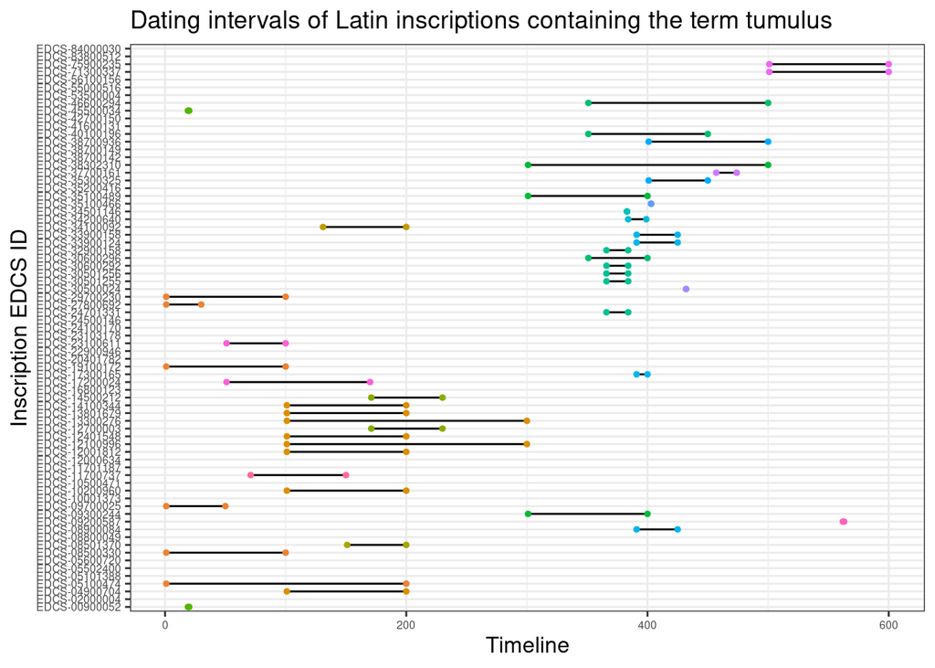

```r
# plotting the dating interval

dated %>% ggplot(aes(x = as.numeric(date_not_before), y = `EDCS-ID`, colour = date_not_before)) + geom_segment(aes(xend = as.numeric(dated$date_not_after), yend = dated$`EDCS-ID`), colour = "black") +
  geom_point(size = 1) +
  geom_point(aes(x = as.numeric(dated$date_not_after)), size = 1) +
  theme_bw() +
  theme(legend.position = "none") +
  labs(x = "Timeline", y = "Inscription EDCS ID", title = "Dating intervals of Latin inscriptions containing the term tumulus") +
  theme(axis.text=element_text(size=6),
        axis.title=element_text(size=12)) -> dated_intervals

dated_intervals
```

```r
# save as a figure
ggsave(plot = dated_intervals, width = 12, height = 10, dpi = 300, filename = "../figures/tumulus_dating.png")
```

[^1]: Aarhus University, Denmark, https://orcid.org/0000-0002-6349-0540